# Homework 2 - INFSCI 2160: Data Mining

#### b) For the best model, compute the odds ratio and interpret the effect of each predictors

```r
# List of the odds ratio
exp(coef(model2$finalModel))
```

**(Intercept)**

0.00193063824620652

**Age**

1.02810923223981

**EducationBachelor**

1.07827282670665

**EducationCollege**

0.4327611935832

**EducationDoctorate**

2.64852952179636

**EducationHSgrad**

0.328758921144939

**EducationMaster**

1.64749120295589

**EducationPreschool**

1.66317428547229e-07

**EducationProfessional**

5.49532855958059

**EducationVocational**

0.369780470663265

**EducationYr10**

0.223571602625633

**EducationYr11**

0.237041467675794

**EducationYr12**

0.195533004177872

**EducationYr1t4**

3.12533354819986e-08

**EducationYr5t6**

0.0614764397161725

**EducationYr7t8**

6.03615732183014e-08

**EducationYr9**

0.0545124169167773

**MaritalDivorced**

0.953201878294915

**MaritalMarried**

14.6693949015795

**`MaritalMarried-spouse-absent`**

1.5700548509872

**MaritalUnmarried**

1.86805835418091

**MaritalWidowed**

1.1987475643449

**OccupationClerical**

3.21247370936756

**OccupationExecutive**

4.78822031478977

**OccupationFarming**

0.850773677161707

**OccupationHome**

4.02946065284187e-06

**OccupationMachinist**

1.64540049252822

**OccupationProfessional**

3.38674903543298

**OccupationProtective**

5.87464762667465

**OccupationRepair**

1.88039684473597

**OccupationSales**

2.53722541911437

**OccupationService**

0.673218184537208

**OccupationSupport**

3.67831936618037

**OccupationTransport**

1.23881802249222

**Income**

1.00000241179142

**GenderMale**

1.22324011726097

**Deductions**

1.00110293225241

**Hours**

1.03561051242822

> To take *Age* as an example, this result means that a change of one unit in the predictor variable *Age* changes the odds of prouductive audit by 1.03 units, while all other variables remaining fixed. Predictor variables such as *EducationProfessional*, *MaritalMarried*, *OccupationExecutive*, *OccupationProtective* have a strong predictive power in this model.

### 4) Apply linear and non-linear regression analysis to predict RISK_Adjustment. Evaluate the models through cross-validation and on holdout (leave-one-out or 10-fold cross-validation) samples. Provide details similar to HW1 (3).

#### hint: treat the given binary values “1/0” as “positive/negative”

#### hint: be careful about missing values in data

> #### Linear Regression

```r
class(ad$RISK_Adjustment)
```

'integer'

```r
class(ad$RISK_Adjustment) <- as.numeric(ad$RISK_Adjustment)
```

```r
library(MASS)
fit_linear0 = lm(data=ad, RISK_Adjustment ~ Age + Employment + Education + Marital +
    Occupation + Income + Gender + Deductions + Hours )
stepAIC(fit_linear0, direction="backward")
```

```
Start:  AIC=34094.02
RISK_Adjustment ~ Age + Employment + Education + Marital + Occupation +
    Income + Gender + Deductions + Hours

             Df  Sum of Sq        RSS   AIC
- Occupation 12  682146975 1.1650e+11 34081
- Gender      1    8017906 1.1583e+11 34092
- Income      1   51112993 1.1587e+11 34093
<none>                     1.1582e+11 34094
- Age         1  180298167 1.1600e+11 34095
- Deductions  1  221021218 1.1604e+11 34096
- Hours       1  254698703 1.1607e+11 34096
- Employment  5  861162431 1.1668e+11 34098
- Education  15 2726644400 1.1855e+11 34108
- Marital     5 2936004271 1.1875e+11 34132

Step:  AIC=34081.16
RISK_Adjustment ~ Age + Employment + Education + Marital + Income +
    Gender + Deductions + Hours

             Df  Sum of Sq        RSS   AIC
- Income      1   53644469 1.1655e+11 34080
- Gender      1   68272678 1.1657e+11 34080
<none>                     1.1650e+11 34081
- Age         1  195979006 1.1670e+11 34082
- Hours       1  227844978 1.1673e+11 34083
- Deductions  1  250967129 1.1675e+11 34083
- Employment  5  778312120 1.1728e+11 34084
- Education  15 4150106259 1.2065e+11 34118
- Marital     5 2942640967 1.1944e+11 34118

Step:  AIC=34080.03
RISK_Adjustment ~ Age + Employment + Education + Marital + Gender +
    Deductions + Hours

             Df  Sum of Sq        RSS   AIC
- Gender      1  117916964 1.1667e+11 34080
<none>                     1.1655e+11 34080
- Age         1  178019422 1.1673e+11 34081
- Hours       1  206590067 1.1676e+11 34081
- Deductions  1  248028126 1.1680e+11 34082
- Employment  5  773495118 1.1733e+11 34083
- Education  15 4126530306 1.2068e+11 34116
- Marital     5 2927361439 1.1948e+11 34117

Step:  AIC=34079.95
RISK_Adjustment ~ Age + Employment + Education + Marital + Deductions +
    Hours

             Df  Sum of Sq        RSS   AIC
<none>                     1.1667e+11 34080
- Hours       1  157838428 1.1683e+11 34081
- Age         1  174517517 1.1685e+11 34081
- Deductions  1  227699209 1.1690e+11 34082
- Employment  5  777203091 1.1745e+11 34083
- Education  15 4174137935 1.2085e+11 34117
- Marital     5 2956496012 1.1963e+11 34117
```

```
Call:
lm(formula = RISK_Adjustment ~ Age + Employment + Education +
    Marital + Deductions + Hours, data = ad)

Coefficients:
                 (Intercept)                           Age
                     871.407                        29.664
         EmploymentPSFederal             EmploymentPSLocal
                   -1405.056                      1058.645
           EmploymentPSState             EmploymentPrivate
                   -1424.297                     -1186.521
           EmploymentSelfEmp             EducationBachelor
                     153.473                      -438.103
            EducationCollege            EducationDoctorate
                   -1424.911                      1206.670
             EducationHSgrad               EducationMaster
                   -2029.293                      1269.895
          EducationPreschool         EducationProfessional
                   -3338.502                      8889.945
         EducationVocational                 EducationYr10
                   -1764.618                      -662.439
               EducationYr11                 EducationYr12
                   -1986.021                     -1923.734
              EducationYr1t4                EducationYr5t6
                   -4874.097                     -3631.372
              EducationYr7t8                  EducationYr9
                   -3113.974                     -3335.555
             MaritalDivorced                MaritalMarried
                    -544.431                      2423.418
MaritalMarried-spouse-absent              MaritalUnmarried
                   -1165.215                       -98.842
              MaritalWidowed                    Deductions
                    -637.381                         1.026
                       Hours
                      26.247
```

```r
fit_linear = lm(data=ad, RISK_Adjustment ~ Age + Employment + Education + Marital + Deductions + Hours)
summary(fit_linear)
```

```
Call:
lm(formula = RISK_Adjustment ~ Age + Employment + Education +
    Marital + Deductions + Hours, data = ad)

Residuals:
   Min     1Q Median     3Q    Max
-14931  -2553   -574    592 104182

Coefficients:
                               Estimate Std. Error t value Pr(>|t|)
(Intercept)                    871.4072  1501.4769   0.580   0.5617
Age                             29.6635    17.7459   1.672   0.0948 .
EmploymentPSFederal          -1405.0565  1165.9778  -1.205   0.2283
EmploymentPSLocal             1058.6452   985.2084   1.075   0.2827
EmploymentPSState            -1424.2973  1158.3859  -1.230   0.2190
EmploymentPrivate            -1186.5212   696.8783  -1.703   0.0888 .
EmploymentSelfEmp              153.4725  1114.1138   0.138   0.8905
EducationBachelor             -438.1027  1068.0887  -0.410   0.6817
EducationCollege             -1424.9106  1049.1925  -1.358   0.1746
EducationDoctorate            1206.6698  1900.6305   0.635   0.5256
EducationHSgrad              -2029.2935  1024.3948  -1.981   0.0477 *
EducationMaster               1269.8955  1279.1680   0.993   0.3210
EducationPreschool           -3338.5015  3380.6744  -0.988   0.3235
EducationProfessional         8889.9449  1925.2078   4.618 4.15e-06 ***
EducationVocational          -1764.6175  1312.5377  -1.344   0.1790
EducationYr10                 -662.4389  1455.9707  -0.455   0.6492
EducationYr11                -1986.0205  1395.8936  -1.423   0.1550
EducationYr12                -1923.7344  2273.4393  -0.846   0.3976
EducationYr1t4               -4874.0974  3678.9572  -1.325   0.1854
EducationYr5t6               -3631.3718  1997.8008  -1.818   0.0693 .
EducationYr7t8               -3113.9745  1710.1412  -1.821   0.0688 .
EducationYr9                 -3335.5549  1860.4342  -1.793   0.0732 .
MaritalDivorced               -544.4310   641.0449  -0.849   0.3958
MaritalMarried                2423.4177   490.8214   4.937 8.62e-07 ***
MaritalMarried-spouse-absent -1165.2152  1791.9553  -0.650   0.5156
MaritalUnmarried               -98.8423  1055.2444  -0.094   0.9254
MaritalWidowed                -637.3808  1298.9160  -0.491   0.6237
Deductions                       1.0260     0.5374   1.909   0.0564 .
Hours                           26.2470    16.5108   1.590   0.1121
---
Signif. codes:  0 '***' 0.001 '**' 0.01 '*' 0.05 '.' 0.1 ' ' 1

Residual standard error: 7903 on 1868 degrees of freedom
Multiple R-squared:  0.09174,	Adjusted R-squared:  0.07813
F-statistic: 6.739 on 28 and 1868 DF,  p-value: < 2.2e-16
```

> #### leave-one-out cross-validation

```r
n = length(ad$RISK_Adjustment)
error = dim(n)
formula = RISK_Adjustment ~ Age + Employment + Education + Marital + Deductions + Hours
for (k in 1:n)
{
  train1 = c(1:n)
  train = train1[train1 != k]
  m2 = lm(formula, data = ad[train, ])
  pred = predict(m2, newdata = ad[-train, ])
  obs = ad$RISK_Adjustment[-train]
  error[k] = obs - pred
}
rmse_linear = sqrt(mean(error^2))
rmse_linear
```

8006.82217350667

> #### Polynomial Regression

> #### find optimal degrees

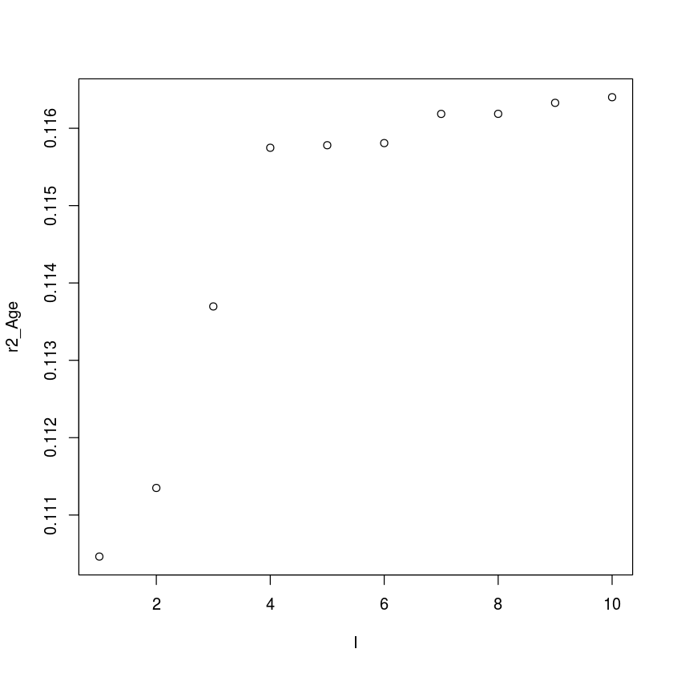

```r
I = seq(1:10)

r2_Age = list()
for (i in 1:10)
{
  fit_poly0 = lm(data=ad, RISK_Adjustment ~ Employment+Education+Marital+Occupation+Gender + poly(Age,degree=i)+poly(Income,degree=10)+poly(Deductions
,degree=10)+poly(Hours,degree=10))
  r2_Age = c(r2_Age,summary(fit_poly0)$r.squared)
}
plot(I,r2_Age)
```

> Thus, set degree of Age = 4

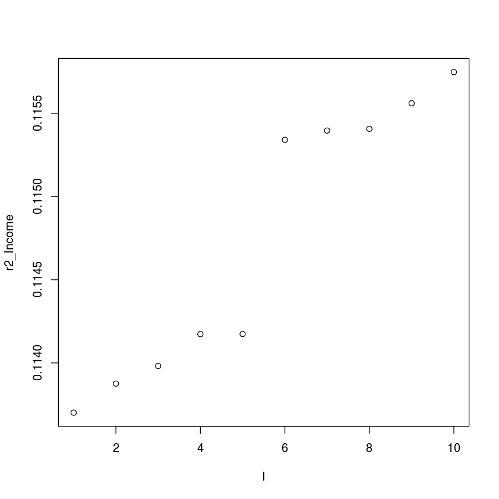

```r
r2_Income = list()
for (i in 1:10)
{
  fit_poly0 = lm(data=ad, RISK_Adjustment ~ Employment+Education+Marital+Occupation+Gender + poly(Age,degree=4)+poly(Income,degree=i)+poly(Deductions
,degree=10)+poly(Hours,degree=10))
  r2_Income = c(r2_Income,summary(fit_poly0)$r.squared)
}
plot(I,r2_Income)
```

> Thus, set degree of Income = 6

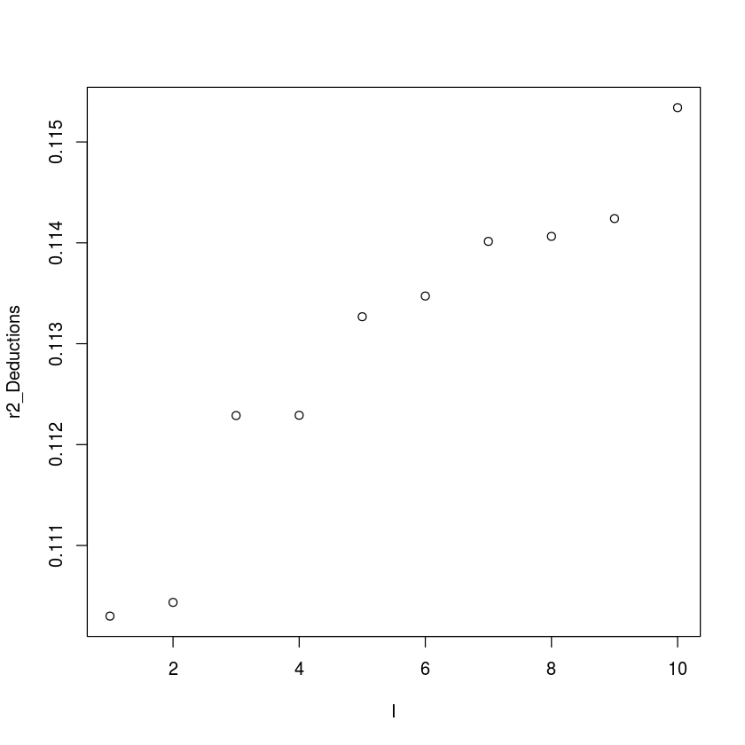

```r
r2_Deductions = list()
for (i in 1:10)
{
  fit_poly0 = lm(data=ad, RISK_Adjustment ~ Employment+Education+Marital+Occupation+Gender + poly(Age,degree=4)+poly(Income,degree=6)+poly(Deductions
,degree=i)+poly(Hours,degree=10))
  r2_Deductions = c(r2_Deductions,summary(fit_poly0)$r.squared)
}
plot(I,r2_Deductions)
```

> Thus, set degree of Deductions = 3

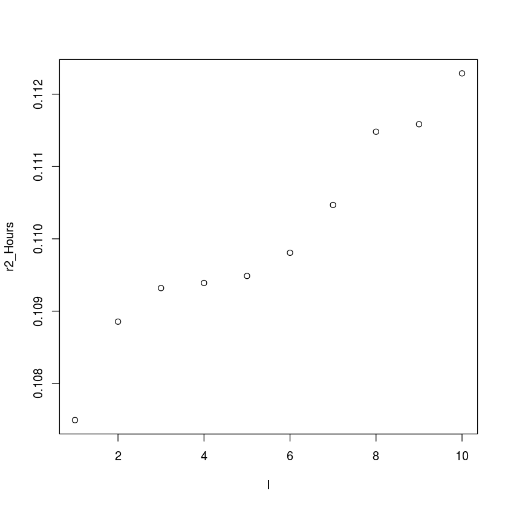

```r
r2_Hours = list()
for (i in 1:10)
{
  fit_poly0 = lm(data=ad, RISK_Adjustment ~ Employment+Education+Marital+Occupation+Gender + poly(Age,degree=4)+poly(Income,degree=6)+poly(Deductions
,degree=3)+poly(Hours,degree=i))
  r2_Hours = c(r2_Hours,summary(fit_poly0)$r.squared)
}
plot(I,r2_Hours)
```

> Thus, set degree of Hours = 3

> #### Fitting

```r
fit_poly0 = lm(data=ad, RISK_Adjustment ~ Employment+Education+Marital+Occupation+Gender + poly(Age,degree=4)+poly(Income,degree=6)+poly(Deductions
,degree=3)+poly(Hours,degree=3))
stepAIC(fit_poly0, direction="backward")
```

```
Start:  AIC=34094.88
RISK_Adjustment ~ Employment + Education + Marital + Occupation +
    Gender + poly(Age, degree = 4) + poly(Income, degree = 6) +
    poly(Deductions, degree = 3) + poly(Hours, degree = 3)

                               Df  Sum of Sq        RSS   AIC
- Occupation                   12  614969533 1.1503e+11 34081
- poly(Income, degree = 6)      6  271843732 1.1469e+11 34087
- Gender                        1    4115912 1.1442e+11 34093
<none>                                       1.1441e+11 34095
- poly(Hours, degree = 3)       3  389559345 1.1480e+11 34095
- poly(Deductions, degree = 3)  3  483601735 1.1490e+11 34097
- Employment                    5  894127467 1.1531e+11 34100
- poly(Age, degree = 4)         4  929918981 1.1534e+11 34102
- Education                    15 2862304997 1.1728e+11 34112
- Marital                       5 2522293769 1.1694e+11 34126

Step:  AIC=34081.05
RISK_Adjustment ~ Employment + Education + Marital + Gender +
    poly(Age, degree = 4) + poly(Income, degree = 6) + poly(Deductions,
    degree = 3) + poly(Hours, degree = 3)

                               Df  Sum of Sq        RSS   AIC
- poly(Income, degree = 6)      6  287557581 1.1532e+11 34074
- Gender                        1   50240667 1.1508e+11 34080
<none>                                       1.1503e+11 34081
- poly(Hours, degree = 3)       3  388607620 1.1542e+11 34081
- poly(Deductions, degree = 3)  3  528526214 1.1556e+11 34084
- Employment                    5  817026208 1.1585e+11 34084
- poly(Age, degree = 4)         4  975835913 1.1601e+11 34089
- Marital                       5 2513463770 1.1754e+11 34112
- Education                    15 4223883527 1.1925e+11 34119

Step:  AIC=34073.79
RISK_Adjustment ~ Employment + Education + Marital + Gender +
    poly(Age, degree = 4) + poly(Deductions, degree = 3) + poly(Hours,
    degree = 3)

                               Df  Sum of Sq        RSS   AIC
- Gender                        1  101034500 1.1542e+11 34073
```

[output cut: 18 more lines]

```
- poly(Age, degree = 4)         4  963853858 1.1638e+11 34081
- Marital                       5 2659697886 1.1808e+11 34107
- Education                    15 4135847944 1.1955e+11 34110

Step:  AIC=34072.52
RISK_Adjustment ~ Employment + Education + Marital + poly(Age,
    degree = 4) + poly(Deductions, degree = 3)

                               Df  Sum of Sq        RSS   AIC
<none>                                       1.1573e+11 34073
- poly(Deductions, degree = 3)  3  500980781 1.1623e+11 34075
- Employment                    5  826830740 1.1655e+11 34076
- poly(Age, degree = 4)         4  973692020 1.1670e+11 34080
- Marital                       5 2859587881 1.1859e+11 34109
- Education                    15 4226529091 1.1995e+11 34111
```

```
Call:
lm(formula = RISK_Adjustment ~ Employment + Education + Marital +
    poly(Age, degree = 4) + poly(Deductions, degree = 3), data = ad)

Coefficients:
                  (Intercept)            EmploymentPSFederal
                       3328.9                        -1547.0
            EmploymentPSLocal              EmploymentPSState
                        895.3                        -1725.8
            EmploymentPrivate              EmploymentSelfEmp
                      -1272.8                          258.0
            EducationBachelor               EducationCollege
                       -366.6                        -1527.2
           EducationDoctorate                EducationHSgrad
                       1233.4                        -2047.3
              EducationMaster             EducationPreschool
                       1033.3                        -3370.8
        EducationProfessional            EducationVocational
                       9035.7                        -1778.4
                EducationYr10                  EducationYr11
                       -845.2                        -2597.5
                EducationYr12                 EducationYr1t4
                      -2569.6                        -5036.9
               EducationYr5t6                 EducationYr7t8
                      -3501.7                        -2832.0
                 EducationYr9                MaritalDivorced
                      -3483.9                         -712.5
               MaritalMarried   MaritalMarried-spouse-absent
                       2359.5                        -1103.7
             MaritalUnmarried                 MaritalWidowed
                       -144.8                         -327.7
       poly(Age, degree = 4)1         poly(Age, degree = 4)2
                      16444.8                       -15960.0
       poly(Age, degree = 4)3         poly(Age, degree = 4)4
                     -17460.6                        17650.9
poly(Deductions, degree = 3)1  poly(Deductions, degree = 3)2
                      15090.0                         5485.6
poly(Deductions, degree = 3)3
                     -16174.6
```

```r
fit_poly = lm(data=ad, formula = RISK_Adjustment ~ Employment + Education + Marital + poly(Age, degree = 4) + poly(Deductions, degree = 3))
summary(fit_poly)
```

```
Call:
lm(formula = RISK_Adjustment ~ Employment + Education + Marital +
    poly(Age, degree = 4) + poly(Deductions, degree = 3), data = ad)

Residuals:
   Min     1Q Median     3Q    Max
-15967  -2516   -631    610 102309

Coefficients:
                              Estimate Std. Error t value Pr(>|t|)
(Intercept)                     3328.9     1212.1   2.746  0.00609 **
EmploymentPSFederal            -1547.0     1165.5  -1.327  0.18458
EmploymentPSLocal                895.3      984.2   0.910  0.36308
EmploymentPSState              -1725.8     1154.2  -1.495  0.13501
EmploymentPrivate              -1272.8      695.0  -1.831  0.06719 .
EmploymentSelfEmp                258.0     1105.5   0.233  0.81550
EducationBachelor               -366.6     1067.5  -0.343  0.73132
EducationCollege               -1527.2     1052.6  -1.451  0.14698
EducationDoctorate              1233.4     1897.2   0.650  0.51571
EducationHSgrad                -2047.3     1026.1  -1.995  0.04617 *
EducationMaster                 1033.3     1278.0   0.809  0.41890
EducationPreschool             -3370.8     3371.6  -1.000  0.31756
EducationProfessional           9035.7     1918.8   4.709 2.67e-06 ***
EducationVocational            -1778.4     1311.6  -1.356  0.17530
EducationYr10                   -845.2     1456.7  -0.580  0.56184
EducationYr11                  -2597.5     1423.1  -1.825  0.06811 .
EducationYr12                  -2569.6     2295.5  -1.119  0.26313
EducationYr1t4                 -5036.9     3670.5  -1.372  0.17014
EducationYr5t6                 -3501.7     2003.6  -1.748  0.08069 .
EducationYr7t8                 -2832.0     1712.5  -1.654  0.09834 .
EducationYr9                   -3483.9     1861.3  -1.872  0.06139 .
MaritalDivorced                 -712.5      668.4  -1.066  0.28658
MaritalMarried                  2359.5      510.3   4.623 4.04e-06 ***
MaritalMarried-spouse-absent   -1103.7     1792.9  -0.616  0.53824
MaritalUnmarried                -144.8     1070.0  -0.135  0.89238
MaritalWidowed                  -327.7     1299.5  -0.252  0.80094
poly(Age, degree = 4)1         16444.8    10213.0   1.610  0.10753
poly(Age, degree = 4)2        -15960.0     8794.6  -1.815  0.06972 .
poly(Age, degree = 4)3        -17460.6     8223.7  -2.123  0.03387 *
poly(Age, degree = 4)4         17650.9     8050.5   2.193  0.02846 *
poly(Deductions, degree = 3)1  15090.0     7953.7   1.897  0.05795 .
poly(Deductions, degree = 3)2   5485.6     7964.4   0.689  0.49105
poly(Deductions, degree = 3)3 -16174.6     7981.9  -2.026  0.04286 *
---
Signif. codes:  0 '***' 0.001 '**' 0.01 '*' 0.05 '.' 0.1 ' ' 1

Residual standard error: 7879 on 1864 degrees of freedom
Multiple R-squared:  0.0991,	Adjusted R-squared:  0.08363
F-statistic: 6.408 on 32 and 1864 DF,  p-value: < 2.2e-16
```

> #### 10-fold cross-validation

```r
# 10-fold cross-validation
n = length(ad$RISK_Adjustment)
error = dim(10)
formula = RISK_Adjustment ~ Employment + Education + Marital + poly(Age, degree = 4) + poly(Deductions, degree = 3)
for (k in 1:10)
{
  test = c(floor((k-1)*n/10+1):floor((k*n/10)))
  train = c(1:n)[-test]
  m2 = lm(formula, data = ad[train, ])
  pred = predict(m2, newdata = ad[test, ])
  obs = ad$RISK_Adjustment[test]
  error[k] = sqrt(mean((obs - pred)^2))
}
rmse_poly = sqrt(mean(error^2))
rmse_poly
```

8004.78311842694

> Therefore, polynomial regression is as bad as the linear regression for this data set.

> [Linear] R-squares(linear) =0.07813 RMSE = 8006.82

> [Poly] R-squares(poly) = 0.08363 RMSE = 8004.78

> Although low R-square values don't always mean bad performance, yet in this case it's really bad, since the R-squares are pretty low for both of the regression models. Actually, the RMSE (around 8000) is higher than a considerable part of the data, which can cause an error larger than 100%. The reason for this is that most of the amount of RISK_Adjustment is zero, which is a very bad condition for numerical regression.